# pointblank

Pointblank is a very useful package for data validation and general quality checks. There are two main tools for this: a `data_scan()` and an `agent`.

A `data_scan()` can give you an output with a high level overview of the data frame. This will tell you about number of columns and observations, number of different variable types, percentage of NAs (missing data). It can also provide more information about each variable in the data.

The `agent` is more powerful as it can validate data based on user defined rules.

#### data_scan()

The data scan output several different groups of information:

- **O**verview
- **V**ariables
- **I**nteractions
- **C**orrelations
- **M**issing
- **S**ample

We are only really interested in the Overview and Variables outputs.

It is best to perform the scan on the raw data once it is imported. This will give you a general idea of how the data look and what issues may need to be dealt with. This will help build the import, data cleaning and variable derivation code.

To perform a data scan the code is as follows:

```r
# Perform data scans
bths_scan <- scan_data(births_data, "OV")
export_report(bths_scan, "./data_reports/birth_data_scan.html")
```

This gives an html output that looks similar to this:

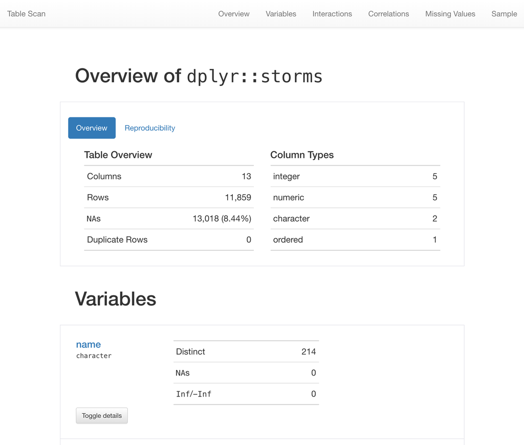

We’ll look at a real output when we get to that stage.

For a more detailed look we can create what’s called an agent. In an agent we can create validation rules. If a value fails the check then the whole record can be output to a csv file.

You can also set action_levels, these give you ‘lights’ that show you if the number of failed values exceed certain percentage thresholds.

```r
al <- action_levels(
  notify_at = 0.01,
  warn_at = 0.02,
  stop_at = 0.1
)

agent <- births_data %>%
  create_agent(actions = al, label = "Births data quality report") %>%
  col_vals_not_between(mother_age_at_birth, left = 0, right = 115, na_pass = TRUE) %>%
  col_vals_gte(registration_date, vars(date_of_birth), na_pass = TRUE) %>%
  col_vals_not_null(date_of_birth) %>%
  col_vals_not_null(mother_age_at_birth) %>%
  col_vals_in_set(sex, set = c("Male","Female")) %>%
  col_vals_not_null(birth_district) %>%
  col_vals_not_null(birth_county) %>%
  col_vals_not_null(birth_subcounty) %>%
  col_vals_not_null(birth_village, actions = c(warn_on_fail(warn_at = 0.07), stop_on_fail(stop_at = 0.2))) %>%
  col_vals_not_null(birth_facility) %>%
  col_vals_not_between(weight_at_birth, left = 230, right = 4000, na_pass = FALSE) %>%
  interrogate()

#### Export reports ####
export_report(agent, "./data_reports/birth_data_report.html")
```

This produces an html output that looks similar to this:

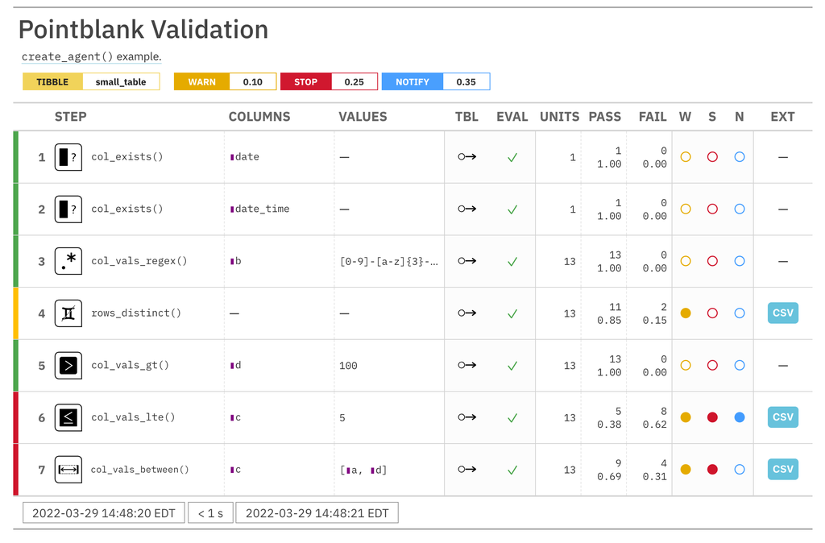

Again, we’ll look at this in more detail later.